# Climate Scientists and Hope

Deborah Apthorp

## Part 1: Data collected in 2017 (Jude’s thesis)

### Background: Surveys and other questions

This data was collected from individuals identified as climate scientists via an online survey (via email invitation) in 2017. It was presented in an Honours thesis by Jude Fox the same year but has not yet been published.

This dataset included some demographic questions (age, gender, country of residence, country of work, nature of work, number of years working, and highest level of education), a question about whether the participants agreed with the IPCC’s findings that anthropogenic climate change is occurring and is a grave threat to the planet (yes, no, or “it’s complicated”), and a set of surveys addressing both qualitative and quantitative questions.

Included surveys were the DASS-21 (Depression, Anxiety and Stress Scale, short form; Henry & Crawford, 2005), the CBI (Copenhagen Burnout Inventory; Borritz & Kristensen, 2004), and two single-item questions about hope for the future and worry about the future, followed by free-text response boxes. There are also some questions from a scale with the prefix “warr_”, - I’m not sure what scale they come from, as it wasn’t included in the thesis.

### Descriptive stats

I first set out to reproduce the results in the thesis. After removing the participant who was marked as having bad data, and the first participant in the dataset who appears to have been piloting the survey, I was able to fairly closely reproduce the results reported in the thesis, with a few exceptions.

Descriptive statistics for age by gender

|  | Male | Female | p | test |
| --- | --- | --- | --- | --- |
| n | 50 | 9 |  |  |
| age (mean (SD)) | 56.78 (11.50) | 46.00 (11.79) | 0.013 |  |

From the thesis: “Fifty-nine climate change scientists volunteered to participate in response to an emailed invitation. The 9 women were aged from 28 to 62 years (M = 46.00, SD = 11.79), and the 50 men from 28 to 80 years (M = 56.78, SD = 11.50).”

Descriptive statistics for key variables

|  | level | Overall |
| --- | --- | --- |
| n |  | 59 |
| age (mean (SD)) |  | 55.14 (12.09) |
| years_working (mean (SD)) |  | 29.49 (12.34) |
| cbi_personal (mean (SD)) |  | 34.11 (16.96) |
| cbi_work (mean (SD)) |  | 29.60 (16.26) |
| hopeful_future_rating (mean (SD)) |  | 55.10 (21.45) |
| dass_total (mean (SD)) |  | 8.37 (6.09) |
| gender (%) | Male | 50 (84.7) |
|  | Female | 9 (15.3) |
| highest_ed (%) | Doctoral Degree | 55 (93.2) |
|  | Masters Degree | 3 ( 5.1) |
|  | Other | 1 ( 1.7) |

This largely reproduces the information in Table 1 in the thesis (minus the population figures).

### Reliability stats

The thesis reports reliability stats for the DASS subscales, although it goes on to use the overall mean rather than any of the subscales, under the label of “mental health”.

DASS depression reliability

|  | raw_alpha | std.alpha | G6(smc) | average_r | S/N | ase | mean | sd | median_r |
| --- | --- | --- | --- | --- | --- | --- | --- | --- | --- |
|  | 0.78 | 0.79 | 0.79 | 0.35 | 3.73 | 0.04 | 0.36 | 0.37 | 0.35 |

DASS anxiety reliability

|  | raw_alpha | std.alpha | G6(smc) | average_r | S/N | ase | mean | sd | median_r |
| --- | --- | --- | --- | --- | --- | --- | --- | --- | --- |
|  | 0.65 | 0.69 | 0.72 | 0.24 | 2.25 | 0.07 | 0.15 | 0.21 | 0.25 |

DASS stress reliability

|  | raw_alpha | std.alpha | G6(smc) | average_r | S/N | ase | mean | sd | median_r |
| --- | --- | --- | --- | --- | --- | --- | --- | --- | --- |
|  | 0.82 | 0.83 | 0.83 | 0.41 | 4.84 | 0.03 | 0.68 | 0.44 | 0.42 |

These reproduce the figures reported in the thesis:

“This scale has good internal reliability with Cronbach’s alphas of .88 for the depression subscale, .82 for anxiety, and .90 for stress (Henry & Crawford, 2005). **Respective Cronbach’s alphas for this sample were .78, .65, and .82.**”

Note that these were calculated using the `psych` package in R

Reliability for the Copenhagen Burnout Inventory was also closely reproduced.

Copenhagen Burnout Inventory Personal Subscale

|  | raw_alpha | std.alpha | G6(smc) | average_r | S/N | ase | mean | sd | median_r |
| --- | --- | --- | --- | --- | --- | --- | --- | --- | --- |
|  | 0.85 | 0.84 | 0.85 | 0.47 | 5.42 | 0.03 | 34.11 | 16.96 | 0.49 |

Copenhagen Burnout Inventory Work Subscale

|  | raw_alpha | std.alpha | G6(smc) | average_r | S/N | ase | mean | sd | median_r |
| --- | --- | --- | --- | --- | --- | --- | --- | --- | --- |
|  | 0.86 | 0.86 | 0.87 | 0.47 | 6.28 | 0.03 | 29.6 | 16.26 | 0.46 |

From the thesis:

“The Copenhagen Burnout Inventory (Borritz & Kristensen, 2004) measures personal-burnout ($\alpha = .87$) and work-burnout ($\alpha = .87$). **Respective Cronbach’s alphas for this sample were .85 and .86.**”

### Hypothesis tests - comparing means to normative sample

Single-sample t-tests for DASS and CBI scales

|  | estimate | statistic | p.value | conf.low | conf.high |
| --- | --- | --- | --- | --- | --- |
| DASS total | 8.37 | -1.33 | 0.187 | 6.79 | 9.96 |
| Personal Burnout | 34.11 | -0.81 | 0.421 | 29.69 | 38.53 |
| Work Burnout | 29.60 | -1.61 | 0.114 | 25.36 | 33.84 |

From the thesis:

“Mental health measured 1.06 points below the general population mean, ***t(58) = -1.33, p = .187, d = 0.14, 95% CI [–0.22, 0.50]**. Personal-burnout measured 1.79 points below the general population mean, **t(58) = -0.81, p = .421, d = -0.11, 95% CI [–0.22, 0.50]**. Work-burnout measured 3.40 points below the general population mean, **t(58) = -1.61, p = .114, d = -0.21, 95% CI [-0.57, 0.15]**. ”

It is clear that the confidence intervals shown above are for the estimate, not the effect size, so let’s have a look at the effect sizes:

Cohen’s d for DASS and CBI scales

| .y. | effsize | conf.low | conf.high | magnitude |
| --- | --- | --- | --- | --- |
| dass_total | -0.17 | -0.47 | 0.07 | negligible |
| cbi_personal | -0.11 | -0.38 | 0.15 | negligible |
| cbi_work | -0.21 | -0.49 | 0.03 | small |

Hmmm. The effect sizes (apart from the DASS total) seem to match, but the CIs are not perfectly reproduced. Maybe this is something about how SPSS does CIs, I guess?

Next up is paired t-tests:

“A paired samples t-test indicated that personal-burnout was higher than work-burnout. This difference was significant, **t(58) = 3.28, p = .002, two‐tailed**, and small, **d = .27, 95% CI [0.01, 0.53]**. The personal-burnout measure was used in the subsequent analyses as it captured more negative affectivity than the work-burnout measure.”

Statistics and effect size for paired t-test between CBI Personal and CBI Work

| estimate | statistic | p.value | d_rm | CI_low | CI_high |
| --- | --- | --- | --- | --- | --- |
| 4.51 | 3.28 | 0.002 | 0.27 | 0.1 | 0.43 |

Again, the statistic, p-value and effect size are reproduced perfectly, but the CI doesn’t seem to match.

### Correlations and multiple regression

The thesis reports that “the association between age and personal-burnout was significant, negative, and medium in size, **r(57) = -.38, p = .001, $r^2$ = .15**.

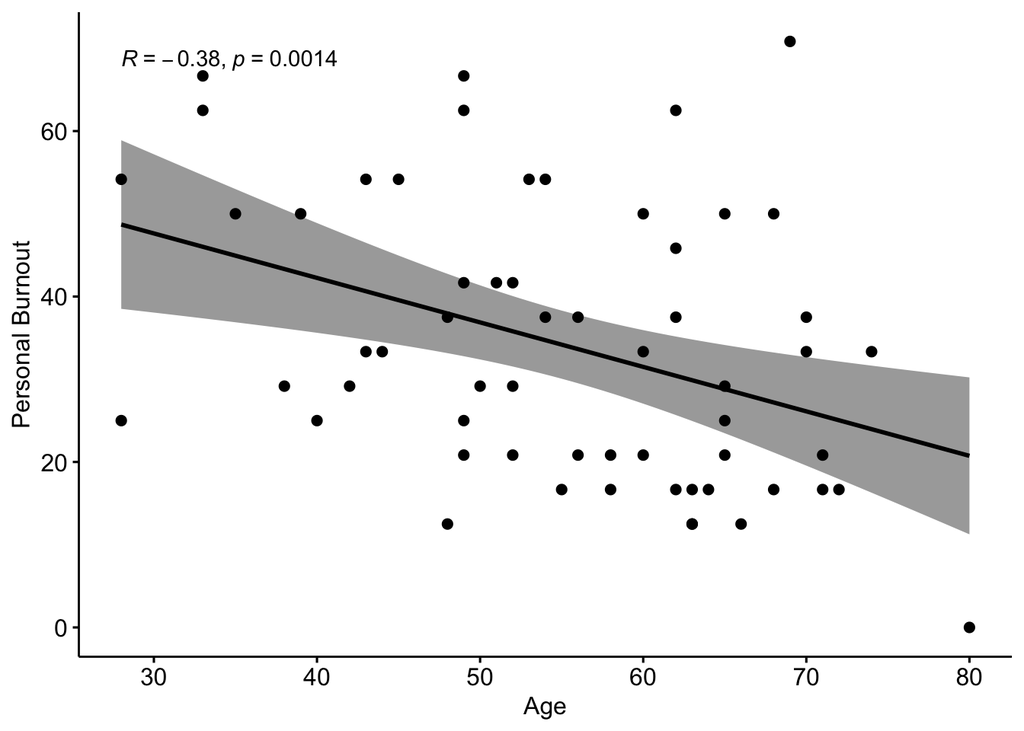

Initially I wondered why the p-value was different, but then I realised that this was a one-tailed test, as the hypothesis was that the relationship would be negative, so that makes sense. So I’ve altered the plot to show that. You can get $r^2$ from $r$, so -0.38339 squared is 0.1469879.

Next we look at the multiple regression/moderation analysis. I used the `lm` package for this, centering the variables as suggested in the thesis.

Coefficients for the multiple regression model of age and hope for the future on personal burnout

|  | Beta | Standard Error | t value | p value |
| --- | --- | --- | --- | --- |
| age | -0.51 | 0.15 | -3.48 | 0.001 |
| hopeful_future_rating | -0.34 | 0.08 | -4.12 | 0.000 |
| age:hopeful_future_rating | -0.01 | 0.01 | -2.24 | 0.029 |

These betas are not standardised betas here - we can get them using `lm.beta`:

Standardised beta values for the multiple regression model of age and hope for the future on personal burnout

|  | x |
| --- | --- |
| age | -0.36 |
| hopeful_future_rating | -0.43 |
| age:hopeful_future_rating | -0.23 |

The whole model is significant, $F$(3, 56) = 12.7719311, $R^2$ = 0.40625, $Adj. R^2$ = 0.374442. This is fairly close to the statistics reported in Table 2 in the thesis.

### Interaction analysis

We can have a look at the patterns of the interaction between age and hope using the `interactions` package, which is similar to the custom SPSS syntax used in the thesis:

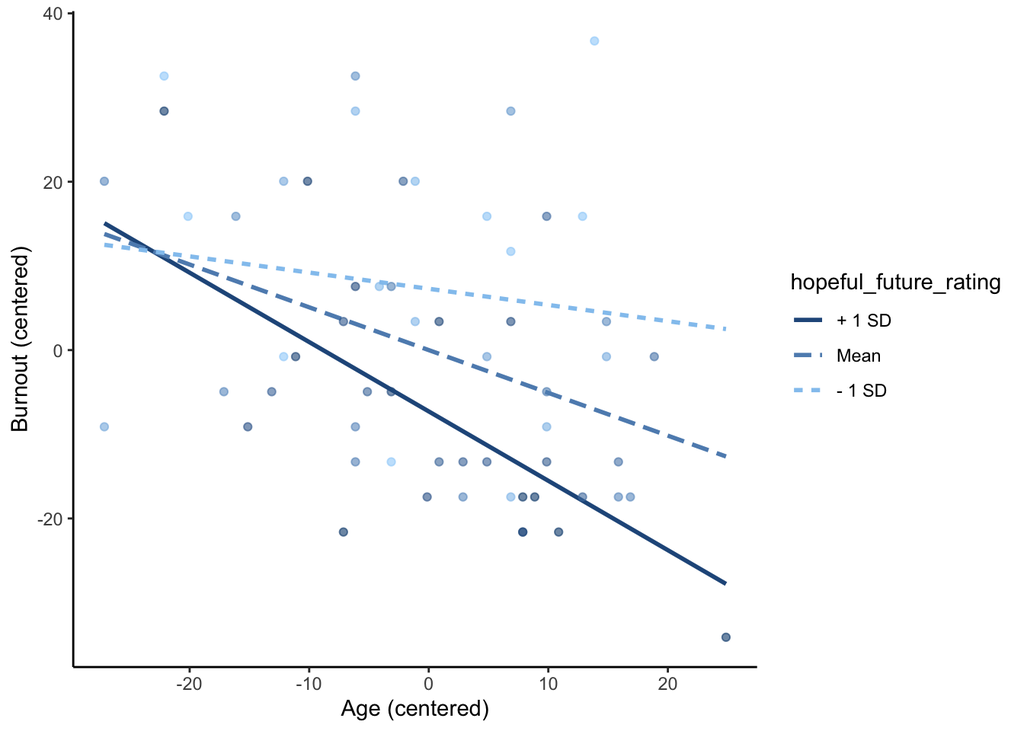

## Part 2: Data collected in 2025

In January 2025 we set out to collect some new data from climate scientists, in the light of Trump’s re-election in the US and renewed fears about policy on climate. On 3rd March 2025, we emailed a list of 7,446 climate scientists from a list compiled from various sources (PubMed, IPCC, etc.). Of these, 7 messages failed and 1492 messages bounced, according to Qualtrics. This means that 5,947 emails were delivered. From these, some respondents emailed us with further suggestions, and we sent 12 emails from these contributed addresses, which resulted in 4 surveys started and 3 finished. From the original list, 544 were started and 402 finished. We compiled a list based on emails that had not “hard” bounced and had not resulted in a survey completion; on 5th June 2025 we sent out a reminder email to this list (5,746 emails), of which 161 bounced. From this email, 236 surveys were started and 159 finished. In total, we now have 567 recorded responses to the survey, a response rate of just under 10 percent.

The survey contained similar demographic questions to the previous survey, and also included a question about the nature of work the respondents were doing.

Scales used were, as before, the Copenhagen Burnout Inventory (CBI), which has personal and work subscales, and the DASS-21, as well as the Hogg Eco-Anxiety Scale, the Short Warwick-Edinburgh Mental Well-being Scale (SWEMWBS), the SPOS (Survey of Perceived Organisational Support), a scale of Coping (from Estonian paper - problem-focused coping, emotion-focused coping, avoidance - maybe let’s do a CFI on the data), and the WAMI (Work and Meaning Inventory), as well as some open-ended questions following two rating scales. Participants were asked to rate how hopeful they felt about the future (on a scale of 1 to 100, from “absolutely no hope” to “extremely hopeful”), followed by three open-ended questions: Why do you feel this way? What makes you hopeful? What makes you feel not hopeful, or affects your ability to feel hopeful?. Finally they were asked to rate how worried they felt about the future, followed by three similar open-ended questions.

Firstly, we might ask whether the figures in this survey are similar to those in the last - are climate scientists more burnt out now than they were in 2017? This sample is much larger than the previous one, and we don’t know yet whether the gender and age balances are similar. Should we also compare to the population mean, and if so, do we have current figures?

Are climate scientists more depressed, anxious and/or stressed then previously? Again, we can compare this to the previous study and/or to the population mean.

Then, also, we can compare hope for the future and worry about the future to the previous survey.

Next we need to consider whether we have any specific hypotheses about the other scales.

NOTES: Mental health - worse because after pandemic? Probably all worse?

Hope for the future & worry - could still compare?

Do American researchers feel lower levels of organisational support than their colleagues in the rest of the world?

Let’s plan the code for analysing the new data.

## Part 2 - descriptive statistics

Descriptive statistics for age by gender, Time 2

|  | Male | Female | Other | p | test |
| --- | --- | --- | --- | --- | --- |
| n | 157 | 250 | 10 |  |  |
| age (mean (SD)) | 49.32 (10.32) | 57.06 (12.62) | 53.33 (14.03) | <0.001 |  |

It looks as if this sample had more women than men (different to Time 1), and the women were significantly older.

Descriptive statistics for key variables, Time 2

|  | level | Overall |
| --- | --- | --- |
| n |  | 427 |
| age (mean (SD)) |  | 54.05 (12.32) |
| cbi_personal_mean (mean (SD)) |  | 41.68 (21.93) |
| cbi_work_mean (mean (SD)) |  | 38.53 (21.59) |
| dass_depression (mean (SD)) |  | 3.42 (3.64) |
| dass_anxiety (mean (SD)) |  | 2.13 (2.79) |
| dass_stress (mean (SD)) |  | 5.49 (4.16) |
| hogg_total_score (mean (SD)) |  | 9.28 (8.04) |
| coping_PF_score (mean (SD)) |  | 4.44 (1.09) |
| coping_EF_score (mean (SD)) |  | 3.16 (1.23) |
| coping_avoidance_score (mean (SD)) |  | 1.91 (0.84) |
| SPOS_score (mean (SD)) |  | 4.05 (1.66) |
| SWEMWS_score (mean (SD)) |  | 3.47 (0.62) |
| WAMI_score (mean (SD)) |  | 42.41 (6.02) |
| gender (%) | Male | 157 (37.6) |
|  | Female | 250 (60.0) |
|  | Other | 10 ( 2.4) |
| education (%) | Other | 5 ( 1.2) |
|  | Bachelor degree | 1 ( 0.2) |
|  | Masters Degree | 10 ( 2.3) |
|  | Doctoral Degree | 410 (96.2) |

## Reliability stats, time 2

Let’s have a look at reliability stats for all the scales.

### DASS subscales

DASS depression reliability, time 2

|  | raw_alpha | std.alpha | G6(smc) | average_r | S/N | ase | mean | sd | median_r |
| --- | --- | --- | --- | --- | --- | --- | --- | --- | --- |
|  | 0.89 | 0.89 | 0.88 | 0.55 | 8.41 | 0.01 | 0.49 | 0.52 | 0.54 |

DASS anxiety reliability, time 2

|  | raw_alpha | std.alpha | G6(smc) | average_r | S/N | ase | mean | sd | median_r |
| --- | --- | --- | --- | --- | --- | --- | --- | --- | --- |
|  | 0.79 | 0.8 | 0.79 | 0.36 | 4.01 | 0.02 | 0.3 | 0.4 | 0.36 |

DASS stress reliability, time 2

|  | raw_alpha | std.alpha | G6(smc) | average_r | S/N | ase | mean | sd | median_r |
| --- | --- | --- | --- | --- | --- | --- | --- | --- | --- |
|  | 0.88 | 0.89 | 0.88 | 0.53 | 7.79 | 0.01 | 0.78 | 0.6 | 0.52 |

### Copenhagen Burnout Inventory (CBI) subscales

CBI (personal) reliability, time 2

|  | raw_alpha | std.alpha | G6(smc) | average_r | S/N | ase | mean | sd | median_r |
| --- | --- | --- | --- | --- | --- | --- | --- | --- | --- |
|  | 0.91 | 0.91 | 0.91 | 0.63 | 10.08 | 0.01 | 41.68 | 21.96 | 0.63 |

CBI (work) reliability, time 2

|  | raw_alpha | std.alpha | G6(smc) | average_r | S/N | ase | mean | sd | median_r |
| --- | --- | --- | --- | --- | --- | --- | --- | --- | --- |
|  | 0.89 | 0.89 | 0.89 | 0.53 | 7.9 | 0.01 | 38.54 | 21.61 | 0.58 |

### Hogg Climate Anxiety scale & subscales

Hogg scale total reliability, time 2

|  | raw_alpha | std.alpha | G6(smc) | average_r | S/N | ase | mean | sd | median_r |
| --- | --- | --- | --- | --- | --- | --- | --- | --- | --- |
|  | 0.92 | 0.92 | 0.94 | 0.47 | 11.51 | 0.01 | 0.72 | 0.62 | 0.44 |

Hogg scale (affective) reliability, time 2

|  | raw_alpha | std.alpha | G6(smc) | average_r | S/N | ase | mean | sd | median_r |
| --- | --- | --- | --- | --- | --- | --- | --- | --- | --- |
|  | 0.89 | 0.89 | 0.86 | 0.66 | 7.85 | 0.01 | 0.68 | 0.74 | 0.64 |

Hogg scale (rumination) reliability, time 2

|  | raw_alpha | std.alpha | G6(smc) | average_r | S/N | ase | mean | sd | median_r |
| --- | --- | --- | --- | --- | --- | --- | --- | --- | --- |
|  | 0.88 | 0.88 | 0.84 | 0.71 | 7.51 | 0.01 | 0.76 | 0.81 | 0.72 |

Hogg scale (behavioural) reliability, time 2

|  | raw_alpha | std.alpha | G6(smc) | average_r | S/N | ase | mean | sd | median_r |
| --- | --- | --- | --- | --- | --- | --- | --- | --- | --- |
|  | 0.83 | 0.83 | 0.76 | 0.62 | 4.86 | 0.01 | 0.52 | 0.68 | 0.62 |

Hogg scale (PI) reliability, time 2

|  | raw_alpha | std.alpha | G6(smc) | average_r | S/N | ase | mean | sd | median_r |
| --- | --- | --- | --- | --- | --- | --- | --- | --- | --- |
|  | 0.89 | 0.89 | 0.85 | 0.73 | 8.32 | 0.01 | 0.91 | 0.84 | 0.75 |

### Coping scale reliability

Problem-focused coping reliability, time 2

|  | raw_alpha | std.alpha | G6(smc) | average_r | S/N | ase | mean | sd | median_r |
| --- | --- | --- | --- | --- | --- | --- | --- | --- | --- |
|  | 0.81 | 0.82 | 0.76 | 0.6 | 4.48 | 0.02 | 4.44 | 1.09 | 0.58 |

Emotion-focused coping reliability, time 2

|  | raw_alpha | std.alpha | G6(smc) | average_r | S/N | ase | mean | sd | median_r |
| --- | --- | --- | --- | --- | --- | --- | --- | --- | --- |
|  | 0.86 | 0.86 | 0.83 | 0.61 | 6.2 | 0.01 | 3.16 | 1.23 | 0.6 |

Avoidance coping reliability, time 2

|  | raw_alpha | std.alpha | G6(smc) | average_r | S/N | ase | mean | sd | median_r |
| --- | --- | --- | --- | --- | --- | --- | --- | --- | --- |
|  | 0.66 | 0.71 | 0.71 | 0.38 | 2.41 | 0.02 | 1.91 | 0.84 | 0.39 |

### SPOS (perceived organisational support) reliability

SPOS reliability, time 2

|  | raw_alpha | std.alpha | G6(smc) | average_r | S/N | ase | mean | sd | median_r |
| --- | --- | --- | --- | --- | --- | --- | --- | --- | --- |
|  | 0.92 | 0.92 | 0.92 | 0.6 | 11.78 | 0.01 | 4.05 | 1.66 | 0.63 |

### Wellbeing (SWEMS) reliability

SWEMS reliability, time 2

|  | raw_alpha | std.alpha | G6(smc) | average_r | S/N | ase | mean | sd | median_r |
| --- | --- | --- | --- | --- | --- | --- | --- | --- | --- |
|  | 0.83 | 0.84 | 0.84 | 0.43 | 5.24 | 0.01 | 3.47 | 0.62 | 0.43 |

### Work as meaning (WAMI) reliability

WAMI reliability, time 2

|  | raw_alpha | std.alpha | G6(smc) | average_r | S/N | ase | mean | sd | median_r |
| --- | --- | --- | --- | --- | --- | --- | --- | --- | --- |
|  | 0.88 | 0.89 | 0.9 | 0.45 | 8.23 | 0.01 | 4.24 | 0.6 | 0.47 |

## Preregistered hypotheses

We preregistered this data analysis at the [OSF](https://osf.io/xegr7/registrations). Here are the analyses for the preregistered hypotheses.

### Hypothesis 1: Mental health at time 2 will be poorer than at Time 1

Hypothesis: 1. Mental ill-health, as assessed by the DASS-21, will be significantly poorer (i.e., greater endorsement of symptoms) in Time 2 than in Time 1.

Preregistered analysis: Hypothesis 1: Mann-Whitney U-tests on DASS subscales between Time 1 and Time 2 participants

Independent samples t-tests (Mann-Whitney U) for DASS subscales from Time 1 to Time 2

|  | estimate | statistic | p.value | conf.low | conf.high |
| --- | --- | --- | --- | --- | --- |
| DASS depression | -2e-05 | 11153.5 | 0.0746 | -Inf | 0e+00 |
| DASS anxiety | -2e-05 | 10046.0 | 0.0046 | -Inf | -1e-04 |
| DASS stress | -1e-05 | 11806.5 | 0.2166 | -Inf | 1e-04 |

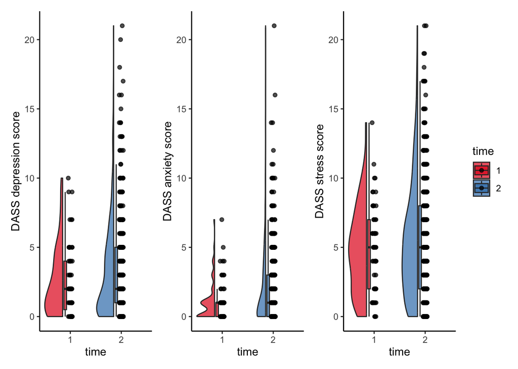

It seems that only anxiety was significantly increased from Time 1 to Time 2. As the sample in Time 2 also includes more women, I think this finding should be taken with caution, though.

### Hypothesis 2: Personal burnout at time 2 will be higher than at Time 1

We also tested work burnout here as an exploratory test.

Independent samples t-tests for Copenhagen Burnout Inventory subscales from Time 1 to Time 2

|  | estimate | statistic | p.value | conf.low | conf.high |
| --- | --- | --- | --- | --- | --- |
| Personal burnout | -7.57 | -3.09 | 0.0013 | -Inf | -3.49 |
| Work burnout | -8.93 | -3.78 | 0.0003 | -13.62 | -4.24 |

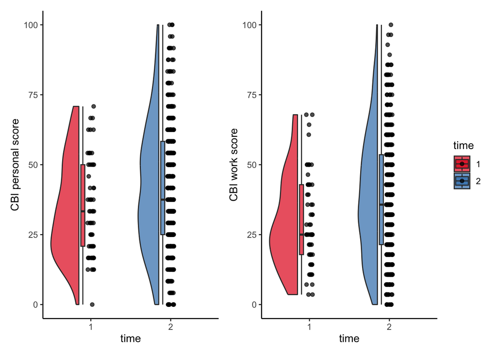

Both personal and work burnout were significantly higher at Time 2 than Time 1.

### Hypothesis 3: At Time 2, wellbeing will be significantly lower for US-based participants compared to their non-US counterparts

Preregistered analysis - Hypothesis 3: General linear model with psychological well-being as the DV, and geographical location (US-based vs. non-US-based) as a factor, with age and gender as control variables.

Coefficients for the general linear model examining the effect of location on wellbeing

|  | Beta | Standard Error | t value | p value |
| --- | --- | --- | --- | --- |
| (Intercept) | 2.67 | 0.15 | 18.07 | 0.0000 |
| USATRUE | -0.01 | 0.08 | -0.13 | 0.8996 |
| age | 0.01 | 0.00 | 4.16 | 0.0000 |
| gender | 0.13 | 0.06 | 2.24 | 0.0259 |

It seems that Hypothesis 3 is not supported - scientists in the USA did not show lower wellbeing than their compatriots in other countries, after controlling for age and gender. Here is a plot to illustrate that.

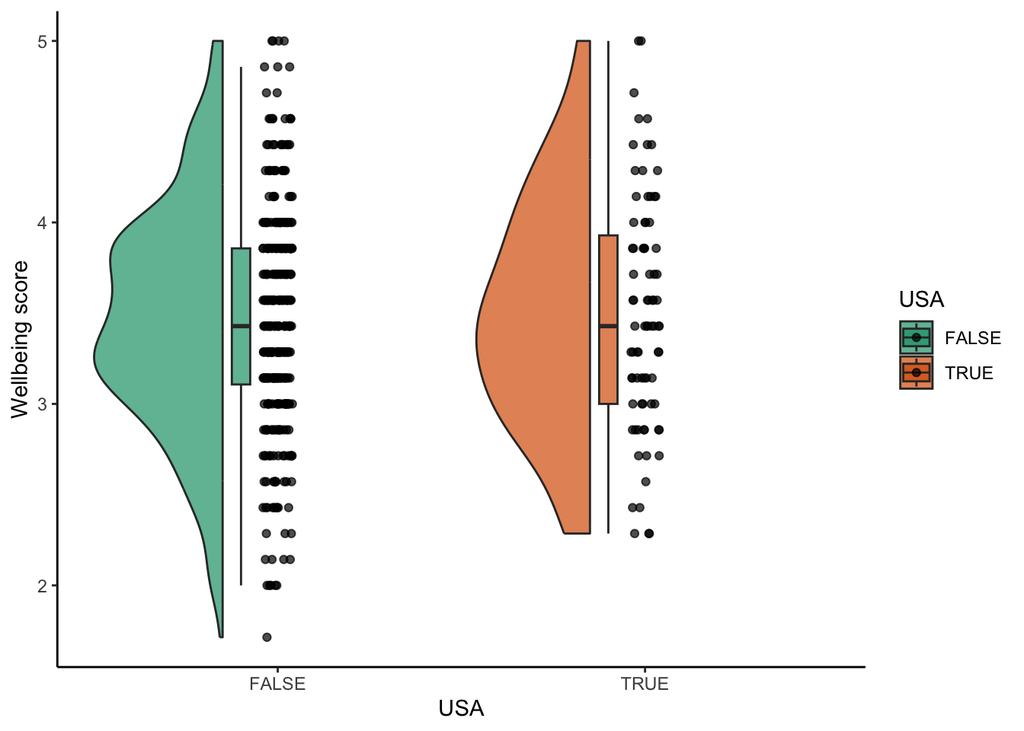

### Hypothesis 4 - personal burnout will be higher than work burnout

Preregistered analysis for Hypothesis 4: Paired samples t-test on all participants between personal burnout and work burnout

Statistics and effect size for paired t-test between CBI Personal and CBI Work (Times 1 and 2 combined)

| estimate | statistic | p.value | d_rm | CI_low | CI_high |
| --- | --- | --- | --- | --- | --- |
| 3.31 | 5.9 | 0 | 0.15 | 0.1 | 0.21 |

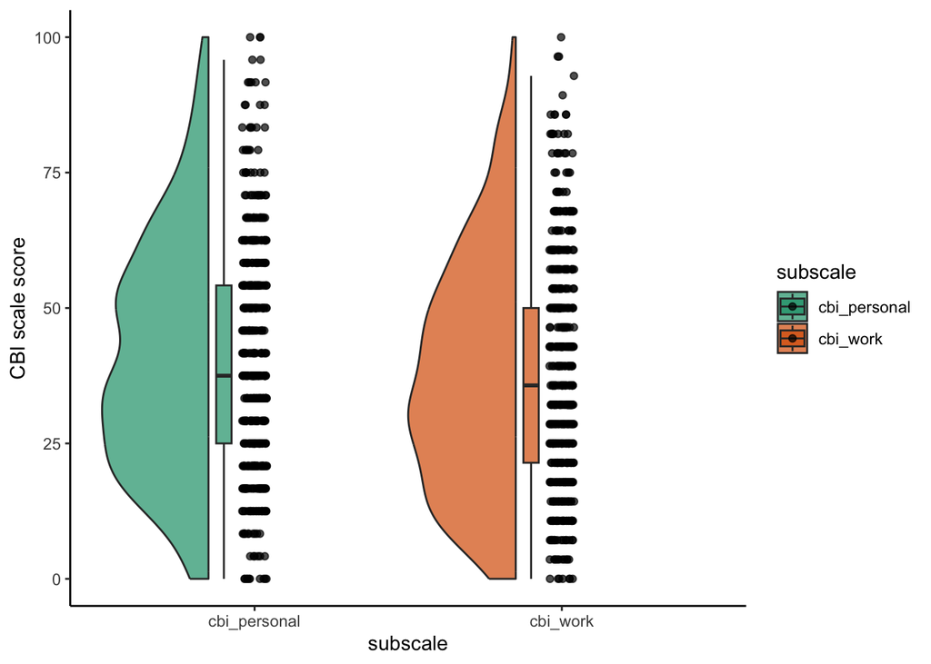

Hypothesis 4 is confirmed - personal burnout is higher than work burnout, as tested by a paired t-test. (I am working on having the plot show connections for each participant!)

### Hypothesis 5 - Problem-focused coping will be associated with greater well-being than emotion-focused coping or avoidance

Hypothesis 5 planned analysis: Multiple regression predicting psychological well-being, IVs of 3 different coping styles (i.e., problem-focused, emotion-focused, avoidance), with age and gender as control variables.

Coefficients for the multiple regression model of coping styles on wellbeing as measured by the SWEMWS scale

|  | Standardized Beta | Beta | Standard Error | t value | p value |
| --- | --- | --- | --- | --- | --- |
| (Intercept) | NA | -0.02 | 0.03 | -0.55 | 0.585 |
| coping_PF_score | 0.06 | 0.03 | 0.03 | 1.09 | 0.274 |
| coping_EF_score | 0.09 | 0.05 | 0.03 | 1.69 | 0.092 |
| coping_avoidance_score | -0.20 | -0.15 | 0.04 | -3.81 | 0.000 |
| age | 0.14 | 0.01 | 0.00 | 2.80 | 0.005 |
| gender | 0.11 | 0.13 | 0.06 | 2.27 | 0.024 |

Here we can see that Hypothesis 5 is not supported - only avoidance is associated (negatively) with wellbeing in the model, after controlling for age and gender. The whole model is significant, $F$(5, 393) = 10.9923505, $R^2$ = 0.122693, $Adj. R^2$ = 0.1115313.

### Hypothesis 6: Organisational support will moderate the relationship between work burnout and well-being

Planned analysis: moderation analysis with organisational support as moderator, IV of work burnout, DV of psychological well-being, age and gender as control variables.

I have carried this analysis out as a multiple regression with interaction. I could use the R toolbox for bootstrapped moderation analysis, but I don’t really think it is necessary.

Coefficients for the multiple regression model of work burnout and perceived organisational support on wellbeing as measured by the SWEMWS scale

|  | Standardized Beta | Beta | Standard Error | t value | p value |
| --- | --- | --- | --- | --- | --- |
| (Intercept) | NA | -0.01 | 0.03 | -0.486 | 0.63 |
| cbi_work_mean | -0.54 | -0.02 | 0.00 | -11.540 | 0.00 |
| SPOS_score | 0.09 | 0.03 | 0.02 | 1.963 | 0.05 |
| age | 0.04 | 0.00 | 0.00 | 0.913 | 0.36 |
| gender | 0.04 | 0.05 | 0.05 | 0.951 | 0.34 |
| cbi_work_mean:SPOS_score | -0.02 | 0.00 | 0.00 | -0.478 | 0.63 |

Here we can see that Hypothesis 6 is also not supported; although work burnout has a large and highly significant negative effect on wellbeing, and perceived organisational support has a a small marginal effect, the interaction between them is not significant. The whole model is significant, $F$(5, 393) = 43.0154694, $R^2$ = 0.3537006, $Adj. R^2$ = 0.345478.

Let’s have a look at that very strong correlation. Also, let’s look at the raw relationship between perceoved organisational support and wellbeing (which is weakly positive in the overall analysis).

[figure not shown]

## Factor analysis

As an exploratory analysis, we also wanted to carry out a factor analysis on the coping scale, since it is a relatively new measure that has not been extensively validated. I chose confirmatory factor analysis in `lavaan`, since there are established subscales onto which the items are designed to load (problem-focused coping, emotion-focused coping and avoidance).

| LHS | OP | RHS | STD.ALL | EST | SE | Z | PVALUE |
| --- | --- | --- | --- | --- | --- | --- | --- |
| Coping_PF | =~ | coping_1 | 0.797 | 1.000 | 0.000 | NA | NA |
| Coping_PF | =~ | coping_2 | 0.718 | 0.933 | 0.102 | 9.186 | 0.000 |
| Coping_PF | =~ | coping_3 | 0.821 | 0.967 | 0.068 | 14.282 | 0.000 |
| Coping_EF | =~ | coping_4 | 0.717 | 1.000 | 0.000 | NA | NA |
| Coping_EF | =~ | coping_5 | 0.865 | 1.162 | 0.083 | 14.062 | 0.000 |
| Coping_EF | =~ | coping_6 | 0.726 | 1.001 | 0.072 | 13.970 | 0.000 |
| Coping_EF | =~ | coping_7 | 0.817 | 1.133 | 0.085 | 13.282 | 0.000 |
| Coping_AV | =~ | coping_8 | 0.291 | 1.000 | 0.000 | NA | NA |
| Coping_AV | =~ | coping_9 | 0.681 | 1.057 | 0.375 | 2.820 | 0.005 |
| Coping_AV | =~ | coping_10 | 0.914 | 1.715 | 0.425 | 4.035 | 0.000 |
| Coping_AV | =~ | coping_11 | 0.551 | 1.622 | 0.277 | 5.861 | 0.000 |
| coping_1 | ~~ | coping_1 | 0.365 | 0.604 | 0.100 | 6.009 | 0.000 |
| coping_2 | ~~ | coping_2 | 0.484 | 0.858 | 0.111 | 7.758 | 0.000 |
| coping_3 | ~~ | coping_3 | 0.326 | 0.475 | 0.073 | 6.498 | 0.000 |
| coping_4 | ~~ | coping_4 | 0.486 | 1.062 | 0.113 | 9.435 | 0.000 |
| coping_5 | ~~ | coping_5 | 0.252 | 0.511 | 0.084 | 6.093 | 0.000 |
| coping_6 | ~~ | coping_6 | 0.473 | 1.007 | 0.085 | 11.863 | 0.000 |
| coping_7 | ~~ | coping_7 | 0.333 | 0.718 | 0.083 | 8.654 | 0.000 |
| coping_8 | ~~ | coping_8 | 0.915 | 2.351 | 0.127 | 18.470 | 0.000 |
| coping_9 | ~~ | coping_9 | 0.537 | 0.282 | 0.053 | 5.357 | 0.000 |
| coping_10 | ~~ | coping_10 | 0.164 | 0.126 | 0.070 | 1.803 | 0.071 |
| coping_11 | ~~ | coping_11 | 0.697 | 1.315 | 0.148 | 8.862 | 0.000 |
| Coping_PF | ~~ | Coping_PF | 1.000 | 1.051 | 0.143 | 7.326 | 0.000 |
| Coping_EF | ~~ | Coping_EF | 1.000 | 1.122 | 0.139 | 8.093 | 0.000 |
| Coping_AV | ~~ | Coping_AV | 1.000 | 0.218 | 0.102 | 2.143 | 0.032 |
| Coping_PF | ~~ | Coping_EF | 0.515 | 0.559 | 0.083 | 6.766 | 0.000 |
| Coping_PF | ~~ | Coping_AV | -0.125 | -0.060 | 0.042 | -1.437 | 0.151 |
| Coping_EF | ~~ | Coping_AV | 0.173 | 0.086 | 0.041 | 2.093 | 0.036 |

Factor Loadings

| Latent Factor | Indicator | B | SE | Z | p-value | Beta |
| --- | --- | --- | --- | --- | --- | --- |
| Coping_PF | coping_1 | 1.000 | 0.000 | NA | NA | 0.797 |
| Coping_PF | coping_2 | 0.933 | 0.102 | 9.186 | 0.000 | 0.718 |
| Coping_PF | coping_3 | 0.967 | 0.068 | 14.282 | 0.000 | 0.821 |
| Coping_EF | coping_4 | 1.000 | 0.000 | NA | NA | 0.717 |
| Coping_EF | coping_5 | 1.162 | 0.083 | 14.062 | 0.000 | 0.865 |
| Coping_EF | coping_6 | 1.001 | 0.072 | 13.970 | 0.000 | 0.726 |
| Coping_EF | coping_7 | 1.133 | 0.085 | 13.282 | 0.000 | 0.817 |
| Coping_AV | coping_8 | 1.000 | 0.000 | NA | NA | 0.291 |
| Coping_AV | coping_9 | 1.057 | 0.375 | 2.820 | 0.005 | 0.681 |
| Coping_AV | coping_10 | 1.715 | 0.425 | 4.035 | 0.000 | 0.914 |
| Coping_AV | coping_11 | 1.622 | 0.277 | 5.861 | 0.000 | 0.551 |

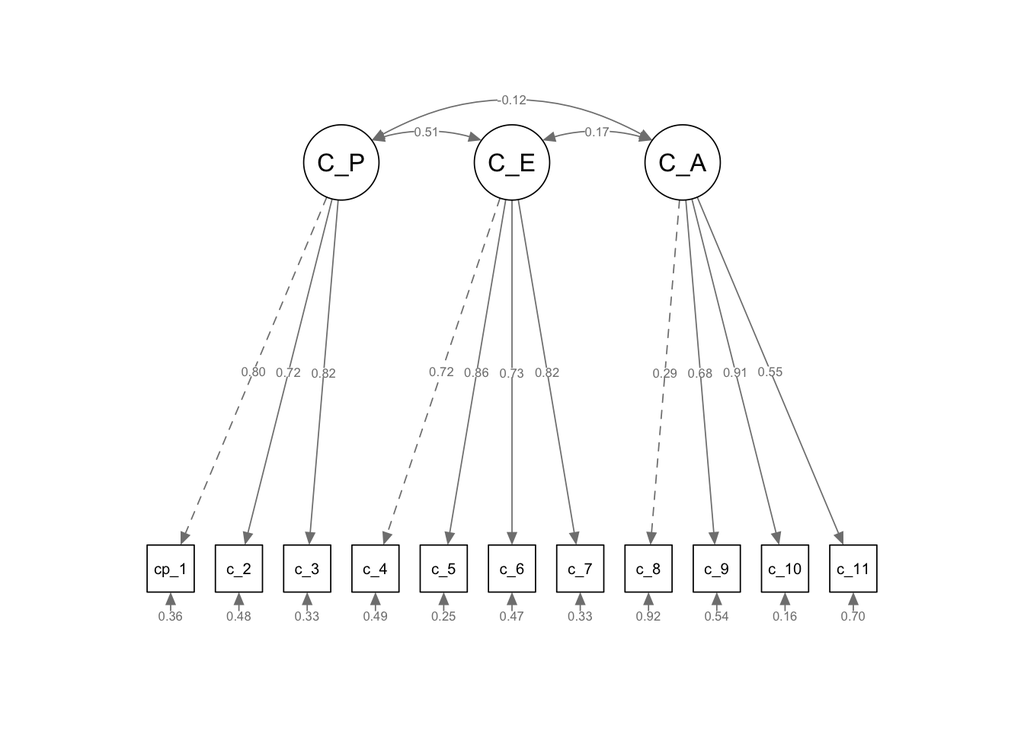

Factor Loadings

| Latent Factor | Indicator | B | SE | Z | p-value | Beta |
| --- | --- | --- | --- | --- | --- | --- |
| Coping_PF | coping_1 | 1.000 | 0.000 | NA | NA | 0.797 |
| Coping_PF | coping_2 | 0.932 | 0.101 | 9.202 | 0 | 0.718 |
| Coping_PF | coping_3 | 0.968 | 0.068 | 14.241 | 0 | 0.822 |
| Coping_EF | coping_4 | 1.000 | 0.000 | NA | NA | 0.717 |
| Coping_EF | coping_5 | 1.162 | 0.083 | 14.031 | 0 | 0.865 |
| Coping_EF | coping_6 | 1.000 | 0.072 | 13.963 | 0 | 0.726 |
| Coping_EF | coping_7 | 1.131 | 0.085 | 13.267 | 0 | 0.816 |
| Coping_AV | coping_9 | 1.000 | 0.000 | NA | NA | 0.652 |
| Coping_AV | coping_10 | 1.808 | 0.372 | 4.858 | 0 | 0.976 |
| Coping_AV | coping_11 | 1.487 | 0.301 | 4.949 | 0 | 0.512 |

Comparison of CFA models with and without item 8

|  | Df | AIC | BIC | Chisq | Chisq diff | Df diff | Pr(>Chisq) |
| --- | --- | --- | --- | --- | --- | --- | --- |
| fit_respecified | 32 | 12261.81 | 12395.68 | 155.24 | NA | NA | NA |
| fit | 41 | 13852.57 | 13998.62 | 270.86 | 119.39 | 9 | 0 |

Just for fanciness, let’s plot a model of the latent variables using `semPaths`:

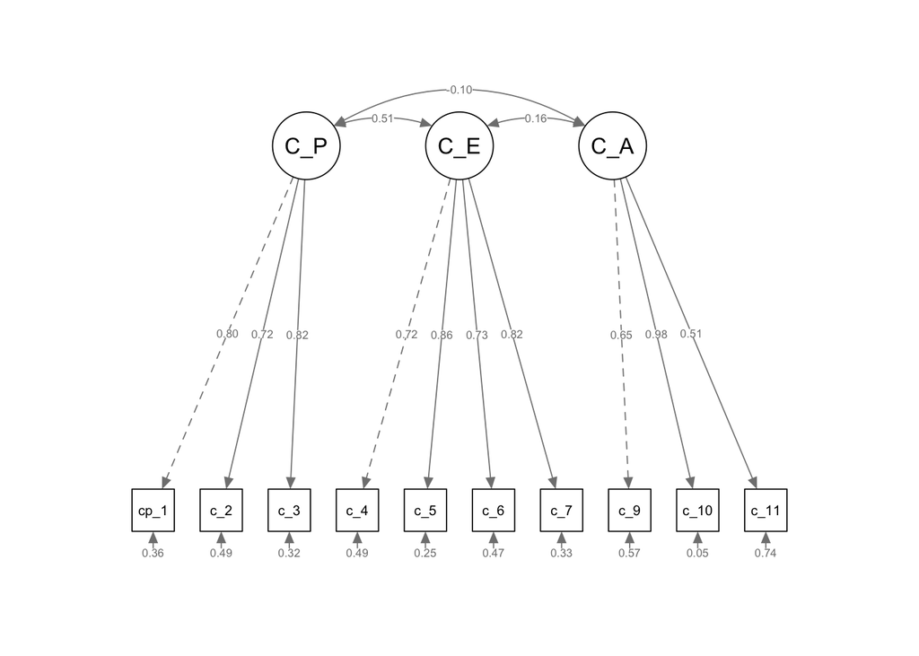

### Documentation

Here is some information about how this file was created.

- File creation date: 2025-09-04
- R version 4.5.0 (2025-04-11)
- R version (short form): 4.5.0
- `mosaic` package version: 1.9.1